# Exploratory Data Analysis

Taylor Bonar, Alexandre Jasserme & Halle Purdom

5/26/2021

# Exploratory Data Analysis

```r
summary(life_expectancy)
```

```
##    Country               Year         Status          LifeExpectancy
##  Length:2938        Min.   :2000   Length:2938        Min.   :36.30
##  Class :character   1st Qu.:2004   Class :character   1st Qu.:63.10
##  Mode  :character   Median :2008   Mode  :character   Median :72.10
##                     Mean   :2008                      Mean   :69.22
##                     3rd Qu.:2012                      3rd Qu.:75.70
##                     Max.   :2015                      Max.   :89.00
##                                                       NA's   :10
##  AdultMortality   InfantDeaths       Alcohol        PercentageExpenditure
##  Min.   :  1.0   Min.   :   0.0   Min.   : 0.0100   Min.   :    0.000
##  1st Qu.: 74.0   1st Qu.:   0.0   1st Qu.: 0.8775   1st Qu.:    4.685
##  Median :144.0   Median :   3.0   Median : 3.7550   Median :   64.913
##  Mean   :164.8   Mean   :  30.3   Mean   : 4.6029   Mean   :  738.251
##  3rd Qu.:228.0   3rd Qu.:  22.0   3rd Qu.: 7.7025   3rd Qu.:  441.534
##  Max.   :723.0   Max.   :1800.0   Max.   :17.8700   Max.   :19479.912
##  NA's   :10                       NA's   :194
##    HepatitisB       Measles              BMI        UnderFiveDeaths
##  Min.   : 1.00   Min.   :     0.0   Min.   : 1.00   Min.   :   0.00
##  1st Qu.:77.00   1st Qu.:     0.0   1st Qu.:19.30   1st Qu.:   0.00
##  Median :92.00   Median :    17.0   Median :43.50   Median :   4.00
##  Mean   :80.94   Mean   :  2419.6   Mean   :38.32   Mean   :  42.04
##  3rd Qu.:97.00   3rd Qu.:   360.2   3rd Qu.:56.20   3rd Qu.:  28.00
##  Max.   :99.00   Max.   :212183.0   Max.   :87.30   Max.   :2500.00
##  NA's   :553                        NA's   :34
##      Polio       TotalExpenditure   Diphtheria       HIV_AIDS
##  Min.   : 3.00   Min.   : 0.370   Min.   : 2.00   Min.   : 0.100
##  1st Qu.:78.00   1st Qu.: 4.260   1st Qu.:78.00   1st Qu.: 0.100
##  Median :93.00   Median : 5.755   Median :93.00   Median : 0.100
##  Mean   :82.55   Mean   : 5.938   Mean   :82.32   Mean   : 1.742
##  3rd Qu.:97.00   3rd Qu.: 7.492   3rd Qu.:97.00   3rd Qu.: 0.800
##  Max.   :99.00   Max.   :17.600   Max.   :99.00   Max.   :50.600
##  NA's   :19      NA's   :226      NA's   :19
##       GDP              Population        Thinness_1_19_years Thinness_5_9_years
##  Min.   :     1.68   Min.   :3.400e+01   Min.   : 0.10       Min.   : 0.10
##  1st Qu.:   463.94   1st Qu.:1.958e+05   1st Qu.: 1.60       1st Qu.: 1.50
##  Median :  1766.95   Median :1.387e+06   Median : 3.30       Median : 3.30
##  Mean   :  7483.16   Mean   :1.275e+07   Mean   : 4.84       Mean   : 4.87
##  3rd Qu.:  5910.81   3rd Qu.:7.420e+06   3rd Qu.: 7.20       3rd Qu.: 7.20
##  Max.   :119172.74   Max.   :1.294e+09   Max.   :27.70       Max.   :28.60
##  NA's   :448         NA's   :652         NA's   :34          NA's   :34
##  IncCompOfResources   Schooling                 Country.factor  Year.factor
##  Min.   :0.0000     Min.   : 0.00   Afghanistan        :  16   2013   : 193
##  1st Qu.:0.4930     1st Qu.:10.10   Albania            :  16   2000   : 183
##  Median :0.6770     Median :12.30   Algeria            :  16   2001   : 183
##  Mean   :0.6276     Mean   :11.99   Angola             :  16   2002   : 183
##  3rd Qu.:0.7790     3rd Qu.:14.30   Antigua and Barbuda:  16   2003   : 183
##  Max.   :0.9480     Max.   :20.70   Argentina          :  16   2004   : 183
##  NA's   :167        NA's   :163     (Other)            :2842   (Other):1830
```

```r
sum(complete.cases(life_expectancy))
```

```
## [1] 1649
```

```r
sum(!complete.cases(life_expectancy))
```

```
## [1] 1289
```

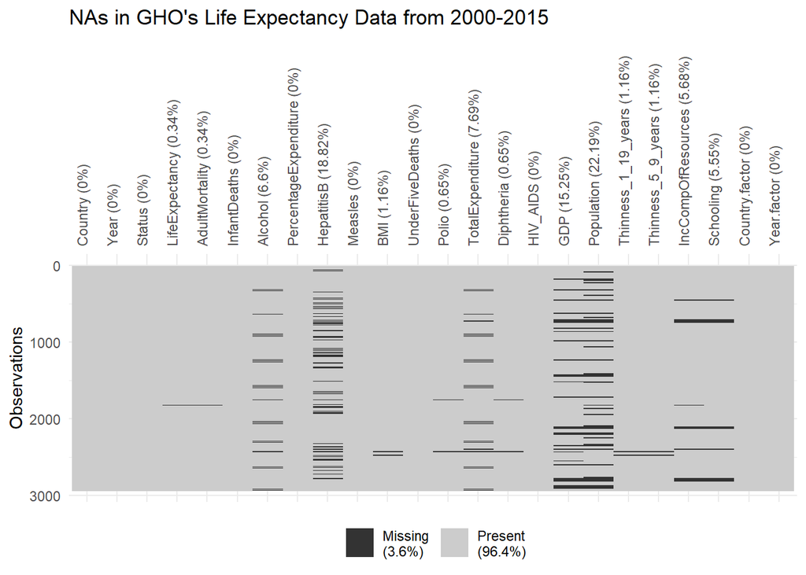

```r
# Create Bird's Eyes View/Overview of Missing Data using naniar lib
vis_miss(life_expectancy, cluster = F) + # Without aggregating observations
  labs(title = "NAs in GHO's Life Expectancy Data from 2000-2015") +
  theme(axis.text.x = element_text(angle=90))
```

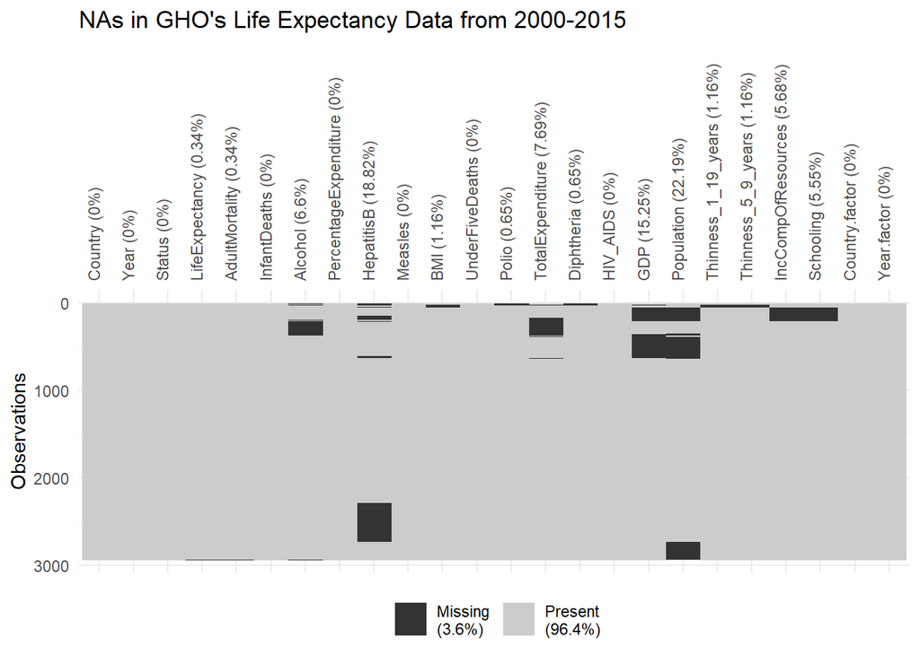

```r
vis_miss(life_expectancy, cluster = T) + # With aggregating observations
  labs(title = "NAs in GHO's Life Expectancy Data from 2000-2015") +
  theme(axis.text.x = element_text(angle=90))
```

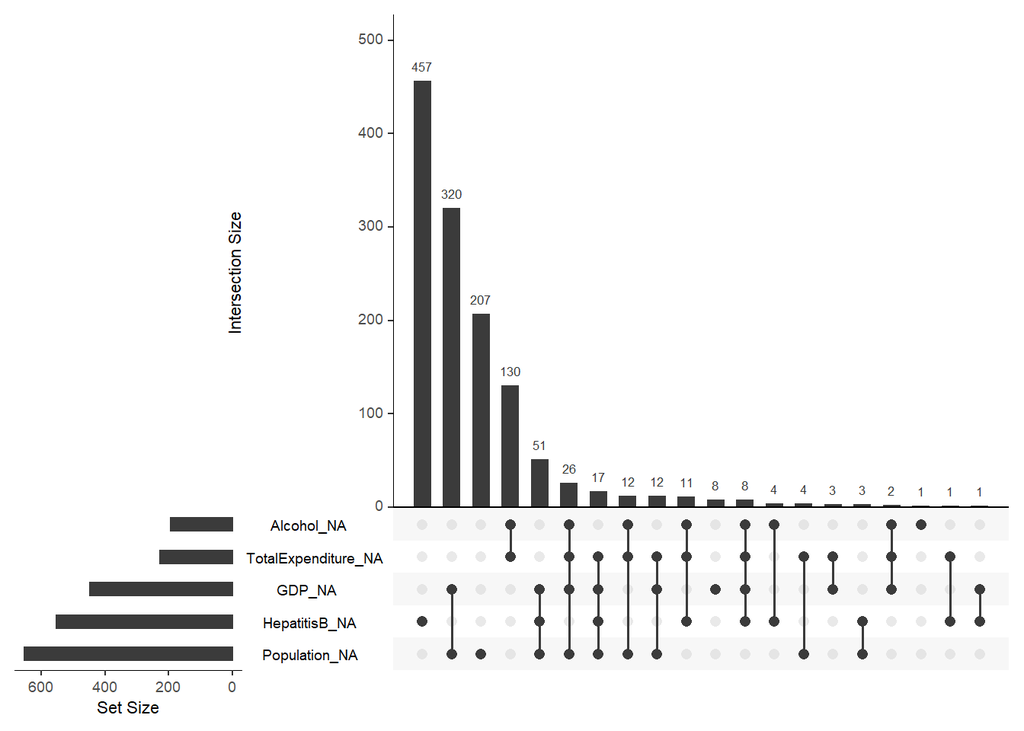

```r
# Can see that Hepatitis B, GDP, Population are about missing data in similar observations

# Visualizing intersection of missing data via upset plot (watch for explanation: https://www.youtube.com/watch?v=-IfF2wGw7Qk)
gg_miss_upset(life_expectancy)
```

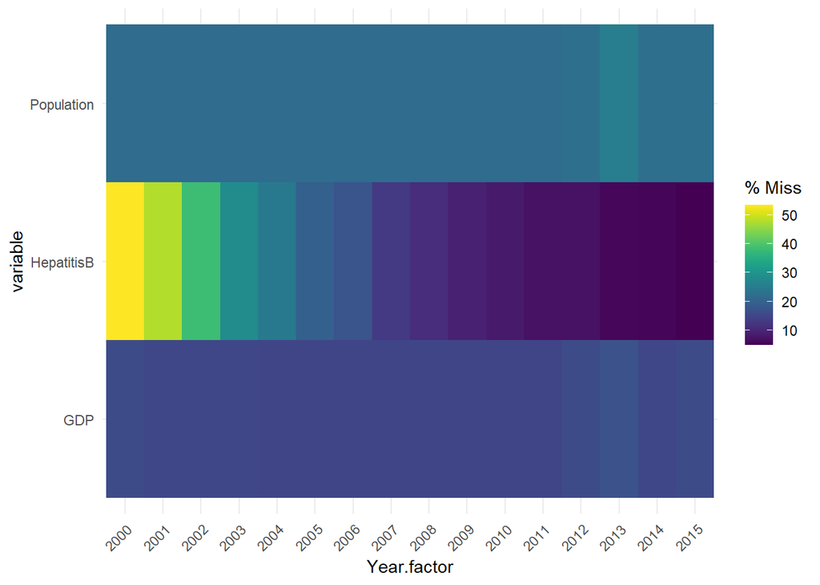

```r
# Can see that there's aa\ linked economic/population problem on the second most missing data between GDP_NA and Population_NA
# While the first column, shows that most individual sets are missing Heptatitis B information
# However, we may want ot explore into TotalExpenditure and Alcohol

# Are any of these overlapping sets or NAs for any particular Country.factor or Year.factor at play for missing data?
gg_miss_fct(x = life_expectancy[,c("HepatitisB","Population","GDP", "Year.factor")], fct = Year.factor)
```

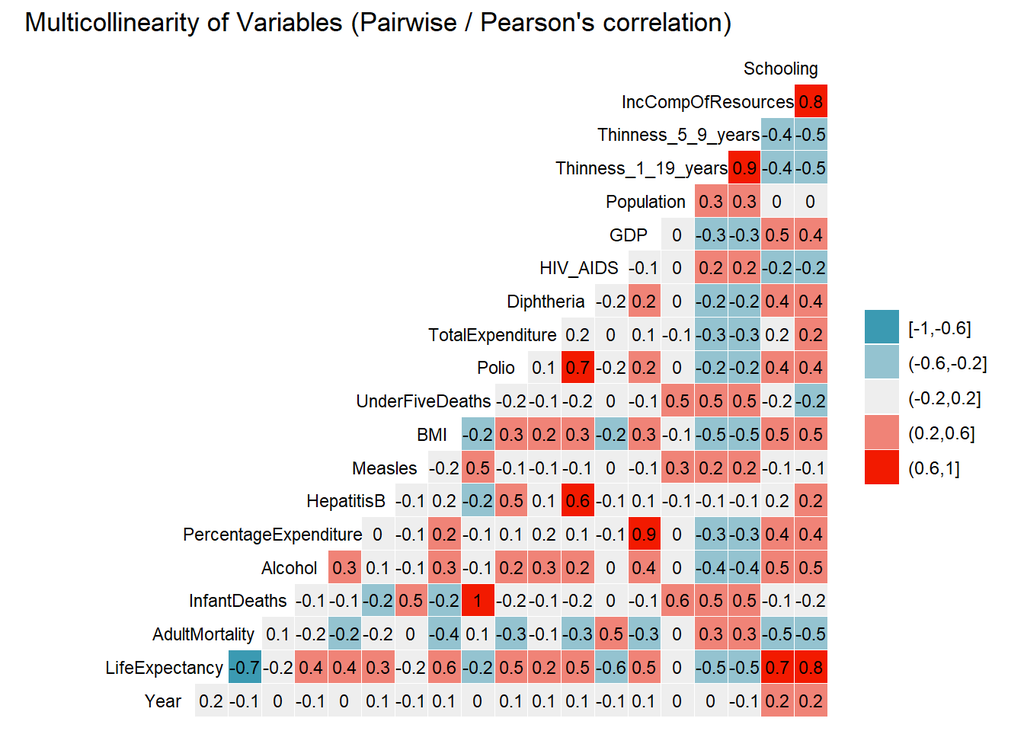

```r
ggcorr(data=life_expectancy, label = T, nbreaks=5, label_size = 3, hjust = 0.9, size = 3, layout.exp = 4) +
  labs(title = "Multicollinearity of Variables (Pairwise / Pearson's correlation)")
```

## Country

```r
# Check for unique countries to match expectation and transform into factor class for later analysis, should be 193 countries
life_expectancy %>%
  group_by(Country) %>%
  summarise(count = length(Country))
```

```
## # A tibble: 193 x 2
##    Country             count
##    <chr>               <int>
##  1 Afghanistan            16
##  2 Albania                16
##  3 Algeria                16
##  4 Angola                 16
##  5 Antigua and Barbuda    16
##  6 Argentina              16
##  7 Armenia                16
##  8 Australia              16
##  9 Austria                16
## 10 Azerbaijan             16
## # ... with 183 more rows
```

```r
unique(life_expectancy[,"Country.factor"])
```

```
##   [1] Afghanistan
##   [2] Albania
##   [3] Algeria
##   [4] Angola
##   [5] Antigua and Barbuda
##   [6] Argentina
##   [7] Armenia
##   [8] Australia
##   [9] Austria
##  [10] Azerbaijan
##  [11] Bahamas
##  [12] Bahrain
##  [13] Bangladesh
##  [14] Barbados
##  [15] Belarus
```

[output cut: 179 more lines]

```r
investigate_missing_column_values("Country")
```

```
## [1] 0
## # A tibble: 0 x 2
## # ... with 2 variables: Year.factor <fct>, missing <int>
## # A tibble: 0 x 2
## # ... with 2 variables: Country.factor <fct>, missing <int>
```

```r
# We will remove any countries for which we don't have 16 years of data: Cook Islands, Dominica, Marshall Islands, Monaco, Nauru, Niue, Palau, Saint Kitts and Nevis, San Marino, Tuvalu
life_expectancy <- life_expectancy [((life_expectancy$Country != "Cook Islands") &
                                       (life_expectancy$Country != "Dominica") &
                                       (life_expectancy$Country != "Marshall Islands") &
                                       (life_expectancy$Country != "Monaco") &
                                       (life_expectancy$Country != "Nauru") &
                                       (life_expectancy$Country != "Niue") &
                                       (life_expectancy$Country != "Palau") &
                                       (life_expectancy$Country != "Saint Kitts and Nevis") &
                                       (life_expectancy$Country != "San Marino") &
                                       (life_expectancy$Country != "Tuvalu")),]

# South Sudan gained independence from the Republic of the Sudan in 2011 (https://en.wikipedia.org/wiki/South_Sudan). Sudan is already in our dataset so the data about South Sudan prior to 2011 is questionable and we will remove South Sudan from the data set
life_expectancy <- life_expectancy [(life_expectancy$Country != "South Sudan"),]

nrow(life_expectancy)
```

```
## [1] 2912
```

```r
# 10 countries with only 1 year of data were removed; 1 country was completely removed and the data frame went from 2938 to 2912 rows, so a difference of 26 rows, which makes sense: 10*1 + 16 = 26
```

## Year

```r
unique(life_expectancy[,"Year"])
```

```
##  [1] 2015 2014 2013 2012 2011 2010 2009 2008 2007 2006 2005 2004 2003 2002 2001
## [16] 2000
```

```r
# Filtering 2013 to 2015:
# - Both 2013 and 2015 have a significant number of missing values
# - 2014 is also removed so that we only have consecutive years in the dataframe
life_expectancy <- life_expectancy [((life_expectancy$Year != 2013) &
                                       (life_expectancy$Year != 2014) &
                                       (life_expectancy$Year != 2015)),]

nrow(life_expectancy)
```

```
## [1] 2366
```

```r
# 3 years were removed and with 182 countries left, the dataframe went from 2912 to 2366 rows, so a difference of 546 rows, which makes sense: 182*3 = 546
```

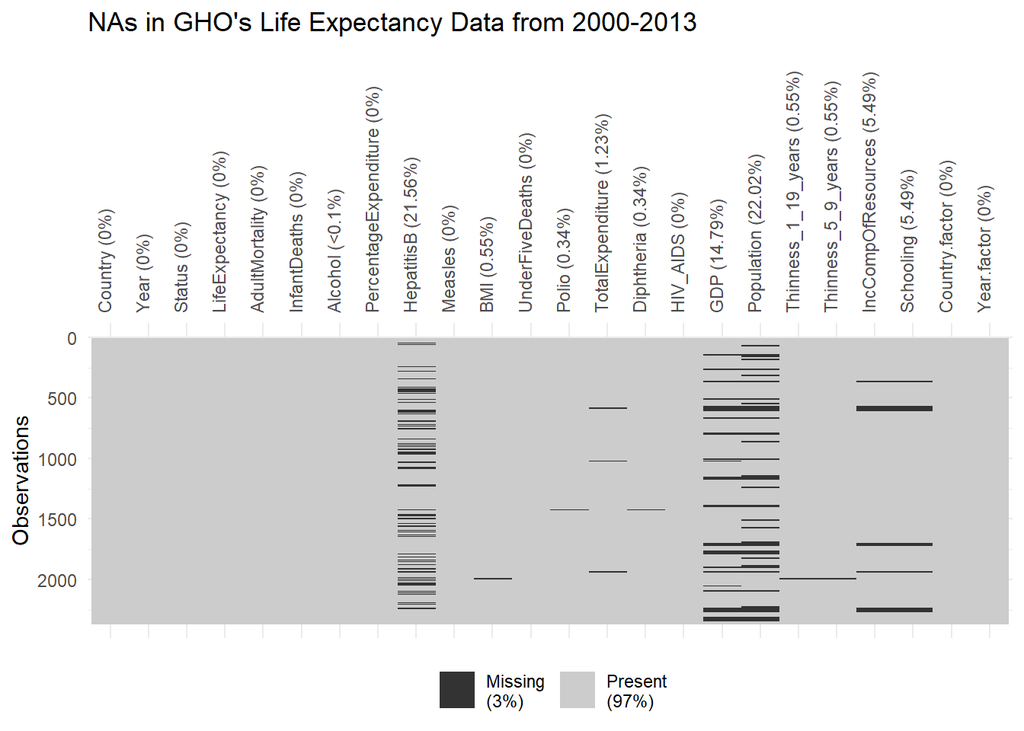

```r
# Create Bird's Eyes View/Overview of Missing Data using naniar lib
vis_miss(life_expectancy, cluster = F) + # Without aggregating observations
  labs(title = "NAs in GHO's Life Expectancy Data from 2000-2013") +
  theme(axis.text.x = element_text(angle=90))
```

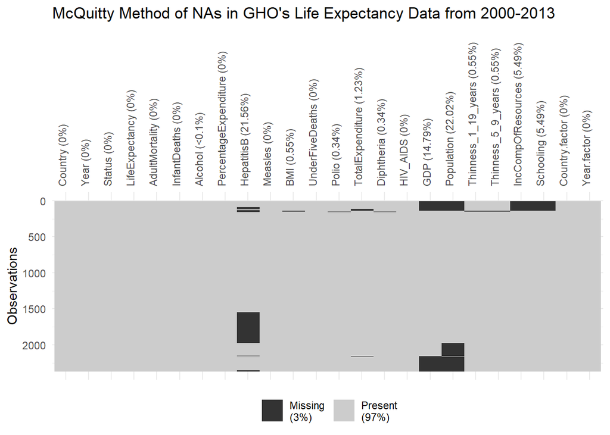

```r
vis_miss(life_expectancy, cluster = T) + # With aggregating observations
  labs(title = "McQuitty Method of NAs in GHO's Life Expectancy Data from 2000-2013") +
  theme(axis.text.x = element_text(angle=90))
```

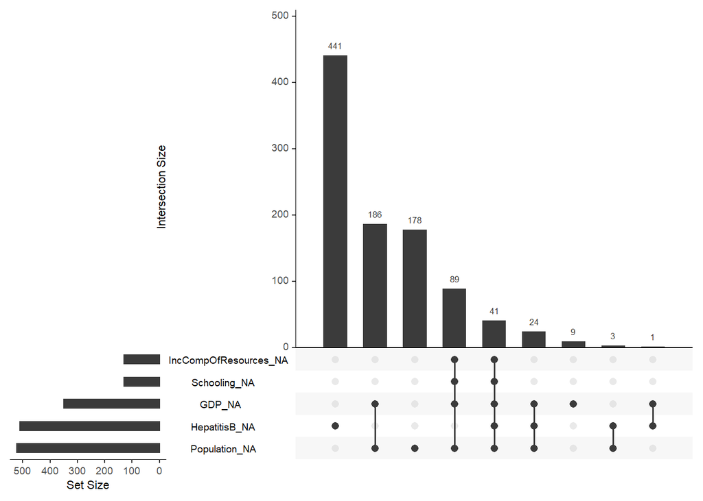

```r
# Can see that Hepatitis B, GDP, Population are about missing data in similar observations

# Visualizing intersection of missing data via upset plot (watch for explanation: https://www.youtube.com/watch?v=-IfF2wGw7Qk)
gg_miss_upset(life_expectancy)
```

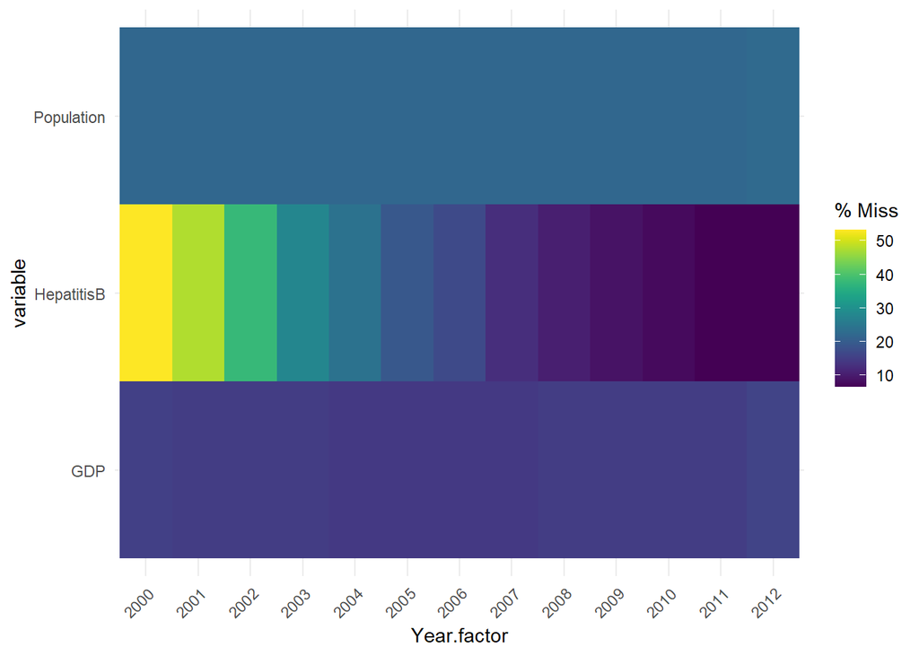

```r
# Can see that there's aa\ linked economic/population problem on the second most missing data between GDP_NA and Population_NA
# While the first column, shows that most individual sets are missing Heptatitis B information
# However, we may want ot explore into TotalExpenditure and Alcohol

# Are any of these overlapping sets or NAs for any particular Country.factor or Year.factor at play for missing data?
gg_miss_fct(x = life_expectancy[,c("HepatitisB","Population","GDP", "Year.factor")], fct = Year.factor)
```

## Status

Some of the data in this column has been changed: - It’s not clear what is the cutline between a Developed and a Developing country - In the original data, the following countries were marked as Developed: Hungary, Italy, Latvia, Lithuania, Poland, Spain, Portugal - Based on this and the GDP per capita (from https://api.worldbank.org/v2/en/indicator/NY.GDP.PCAP.PP.CD?downloadformat=csv, using data from 2015), the Status for the following countries will be changed from Developing to Developed: Bahamas, Bahrain, Canada, Finland, France, Greece, Israel, Monaco, Qatar, Republic of Korea, San Marino, Saudi Arabia, United Arab Emirates - note that we already removed Monaco and San Marino from the dataset based on having data for only 1 year

```r
print(paste0("Before change: number of rows with Developed: ", sum(life_expectancy$Status == "Developed")))
```

```
## [1] "Before change: number of rows with Developed: 416"
```

```r
print(paste0("Before change: number of rows with Developing: ", sum(life_expectancy$Status == "Developing")))
```

```
## [1] "Before change: number of rows with Developing: 1950"
```

```r
life_expectancy$Status <- ifelse(life_expectancy$Country %in% c('Bahamas', 'Bahrain', 'Canada', 'Finland', 'France', 'Greece', 'Israel', 'Monaco', 'Qatar', 'Republic of Korea', 'San Marino', 'Saudi Arabia', 'United Arab Emirates'), "Developed", life_expectancy$Status)
print(paste0("After change: number of rows with Developed: ", sum(life_expectancy$Status == "Developed")))
```

```
## [1] "After change: number of rows with Developed: 559"
```

```r
print(paste0("After change: number of rows with Developing: ", sum(life_expectancy$Status == "Developing")))
```

```
## [1] "After change: number of rows with Developing: 1807"
```

```r
life_expectancy[,'Status'] <- factor(life_expectancy[,'Status'])

# Adding a numeric column for status to use it when building regression models
mapping <- c("Developed" = 1, "Developing" = 0)
life_expectancy$Developed <- mapping[life_expectancy$Status]
```

After the change, the number of rows with Developed increased by 559-416=143 (with a corresponding decrease for the rows with Developing), which makes sense because the Status was updated for 11 countries (since Monaco and San Marino are no longer part of the dataset) and we have 13 rows left for all remaining countries (for years 2000 to 2012): 11*13 = 143

## Life expectancy

Description (from WHO): This seems to be “Life expectancy at birth (years)” (the other option “Life expectancy at age 60 (years)” is not consistent with the data) Missing Values: 10 out of entire dataset, after range restriction no missing values remain

```r
investigate_missing_column_values("LifeExpectancy")
```

```
## [1] 0
## # A tibble: 0 x 2
## # ... with 2 variables: Year.factor <fct>, missing <int>
## # A tibble: 0 x 2
## # ... with 2 variables: Country.factor <fct>, missing <int>
```

## Adult Mortality

Description: Adult Mortality Rates of both sexes (probability of dying between 15 and 60 years per 1000 population) Missing Values: 10 out of entire dataset, after range restriction no missing values remain

```r
investigate_missing_column_values("AdultMortality")
```

```
## [1] 0
## # A tibble: 0 x 2
## # ... with 2 variables: Year.factor <fct>, missing <int>
## # A tibble: 0 x 2
## # ... with 2 variables: Country.factor <fct>, missing <int>
```

## infant deaths

Description: Number of Infant Deaths per 1000 population The maximum of 1800.0 seems to be inaccurate (India 2000-2012)

```r
summary(life_expectancy$InfantDeaths)
```

```
##    Min. 1st Qu.  Median    Mean 3rd Qu.    Max.
##    0.00    0.00    3.00   31.78   22.00 1800.00
```

```r
investigate_over1000("InfantDeaths")
```

```
## [1] 13
## # A tibble: 13 x 2
##     Year missing
##    <int>   <int>
##  1  2000       1
##  2  2001       1
##  3  2002       1
##  4  2003       1
##  5  2004       1
##  6  2005       1
##  7  2006       1
##  8  2007       1
##  9  2008       1
## 10  2009       1
## 11  2010       1
## 12  2011       1
## 13  2012       1
## # A tibble: 1 x 2
##   Country missing
##   <chr>     <int>
## 1 India        13
```

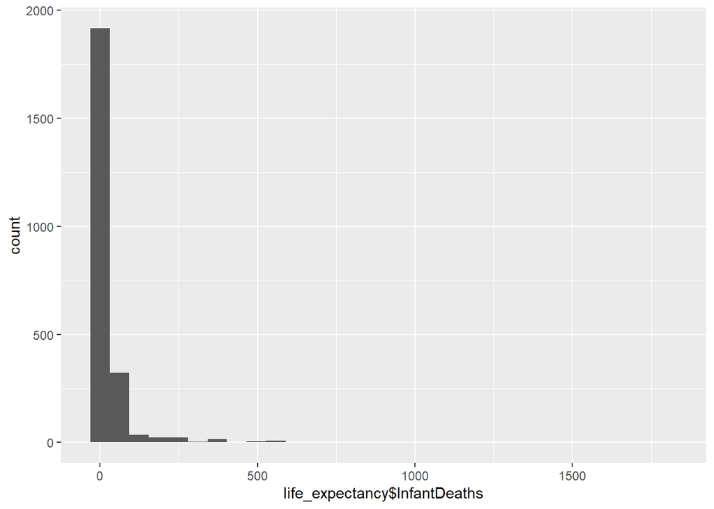

```r
#India 2000-2012 https://data.worldbank.org/indicator/SP.DYN.IMRT.IN

life_expectancy %>% ggplot(aes(x=life_expectancy$InfantDeaths))+geom_histogram()
```

```r
investigate_over200("InfantDeaths")
```

```
## [1] 74
## # A tibble: 13 x 2
##     Year missing
##    <int>   <int>
##  1  2000       7
##  2  2001       7
##  3  2002       7
##  4  2003       6
##  5  2004       6
##  6  2005       6
##  7  2006       5
##  8  2007       5
##  9  2008       5
## 10  2009       5
## 11  2010       5
## 12  2011       5
## 13  2012       5
## # A tibble: 7 x 2
##   Country                          missing
##   <chr>                              <int>
## 1 Bangladesh                             3
## 2 China                                 13
## 3 Democratic Republic of the Congo      13
## 4 Ethiopia                               6
## 5 India                                 13
## 6 Nigeria                               13
## 7 Pakistan                              13
```

```r
#Bangladesh- incorrect
#China- incorrect
#Democratic Republic of Congo- incorrect
#Ethiopia- incorrect
#Nigeria- incorrect
#Pakistan- incorrect

###DATA PREP: Merge Function for missing/incorrect data
# Fill incorrect InfantDeaths data from secondary source: World Banks -- indicator code:  SP.DYN.IMRT.IN
wb_infant <- wb_data(indicator = "SP.DYN.IMRT.IN", country = "countries_only", start_date = 2000, end_date = 2015)
# Grab only necessary columns and map to match dataset

wb_infant <- wb_infant %>% select(date, SP.DYN.IMRT.IN , country)
colnames(wb_infant) = c("Year", "InfantDeaths", "Country")

# wb_infant <- wb_infant %>% select(date, SH.DYN.MORT , country)
# colnames(wb_infant) = c("Year", "InfantDeaths", "Country")
```

## Alcohol

Description: Alcohol, recorded per capita (15+) consumption (in liters of pure alcohol) Missing values: only 1 value is missing for Montenegro in 2005; the value for 2004 is 0.01 and the value for 2006 is 5.38 so we will just leave the cell blank instead of trying to average the previous and following year. Data accuracy: The data seems to make sense for the most part (reasonable min and max, low consumption in mainly Muslim countries, for example); there are some exceptions, see for example the comment above for Montenegro

```r
investigate_missing_column_values("Alcohol")
```

```
## [1] 1
## # A tibble: 1 x 2
##   Year.factor missing
##   <fct>         <int>
## 1 2005              1
## # A tibble: 1 x 2
##   Country.factor missing
##   <fct>            <int>
## 1 Montenegro           1
```

## percentage expenditure

Description: Expenditure on health as a percentage of Gross Domestic Product per capita(%) A lot of problem in this column, for example: - Min.: 0.000  
- Max.: 19479.912

## Hepatitis B

Description: Hepatitis B (HepB) immunization coverage among 1-year-olds (%) 500 N/A (out of almost 3,000 observations) -> We have fewer than 80% of the value so consider dropping this column

```r
investigate_missing_column_values("HepatitisB")
```

```
## [1] 510
## # A tibble: 13 x 2
##    Year.factor missing
##    <fct>         <int>
##  1 2000             97
##  2 2001             87
##  3 2002             69
##  4 2003             51
##  5 2004             44
##  6 2005             35
##  7 2006             31
##  8 2007             23
##  9 2008             19
## 10 2009             16
## 11 2010             14
```

[output cut: 16 more lines]

```r
miss_var_summary(life_expectancy)
```

```
## # A tibble: 25 x 3
##    variable            n_miss pct_miss
##    <chr>                <int>    <dbl>
##  1 Population             521   22.0
##  2 HepatitisB             510   21.6
##  3 GDP                    350   14.8
##  4 IncCompOfResources     130    5.49
##  5 Schooling              130    5.49
##  6 TotalExpenditure        29    1.23
##  7 BMI                     13    0.549
##  8 Thinness_1_19_years     13    0.549
##  9 Thinness_5_9_years      13    0.549
## 10 Polio                    8    0.338
## # ... with 15 more rows
```

```r
# https://www.who.int/data/gho/data/indicators/indicator-details/GHO/hepatitis-b-(hepb3)-immunization-coverage-among-1-year-olds-(-)

hepB <- read.csv("./data/WSH4_117.csv", header = T, skip=1)
colnames(hepB) <- sub("X", "", colnames(hepB))
hepB <- hepB %>% select(-("2013":"2019") & -("1989":"1999"))

# Merge life_expectancy and GDP_per_capita on Year and Country to fill in GDP
# life_expectancy <- left_join(life_expectancy, hepB, by = c("Country", "Year")) %>%
#     mutate(GDP = coalesce(GDP.x, GDP.y)) %>%
#     select(-GDP.x,-GDP.y)

miss_var_summary(life_expectancy)
```

```
## # A tibble: 25 x 3
##    variable            n_miss pct_miss
##    <chr>                <int>    <dbl>
##  1 Population             521   22.0
##  2 HepatitisB             510   21.6
##  3 GDP                    350   14.8
##  4 IncCompOfResources     130    5.49
##  5 Schooling              130    5.49
##  6 TotalExpenditure        29    1.23
##  7 BMI                     13    0.549
##  8 Thinness_1_19_years     13    0.549
##  9 Thinness_5_9_years      13    0.549
## 10 Polio                    8    0.338
## # ... with 15 more rows
```

## Measles

Measles - number of reported cases per 1000 population A lot of problem in this column, for example: - Max.: 212183.0

```r
investigate_missing_column_values("Measles")
```

```
## [1] 0
## # A tibble: 0 x 2
## # ... with 2 variables: Year.factor <fct>, missing <int>
## # A tibble: 0 x 2
## # ... with 2 variables: Country.factor <fct>, missing <int>
```

## BMI

From WHO: It is defined as a person’s weight in kilograms divided by the square of his height in meters (kg/m2). The WHO definition is: - a BMI greater than or equal to 25 is overweight - a BMI greater than or equal to 30 is obesity.

Missing values: very small number of missing values (34 in the whole data set) Data accuracy: A lot of problem in this column, for example: - Min.: 1.00 - Max.: 87.30 It’s not even consistent within a country, for example in China: - in 2013: 3.9 - In 2015: 32.9

We may need to consider dropping this column. For now, we will keep it and see if it gets selected for the model.

```r
investigate_missing_column_values("BMI")
```

```
## [1] 13
## # A tibble: 13 x 2
##    Year.factor missing
##    <fct>         <int>
##  1 2000              1
##  2 2001              1
##  3 2002              1
##  4 2003              1
##  5 2004              1
##  6 2005              1
##  7 2006              1
##  8 2007              1
##  9 2008              1
## 10 2009              1
## 11 2010              1
## 12 2011              1
## 13 2012              1
## # A tibble: 1 x 2
##   Country.factor missing
##   <fct>            <int>
## 1 Sudan               13
```

## under-five deaths

Not sure if it’s a rate for 1000 population, WHO site not clear.

```r
summary(life_expectancy$UnderFiveDeaths)
```

```
##    Min. 1st Qu.  Median    Mean 3rd Qu.    Max.
##    0.00    0.00    4.00   44.32   29.00 2500.00
```

```r
investigate_over1000("UnderFiveDeaths")
```

```
## [1] 13
## # A tibble: 13 x 2
##     Year missing
##    <int>   <int>
##  1  2000       1
##  2  2001       1
##  3  2002       1
##  4  2003       1
##  5  2004       1
##  6  2005       1
##  7  2006       1
##  8  2007       1
##  9  2008       1
## 10  2009       1
## 11  2010       1
## 12  2011       1
## 13  2012       1
## # A tibble: 1 x 2
##   Country missing
##   <chr>     <int>
## 1 India        13
```

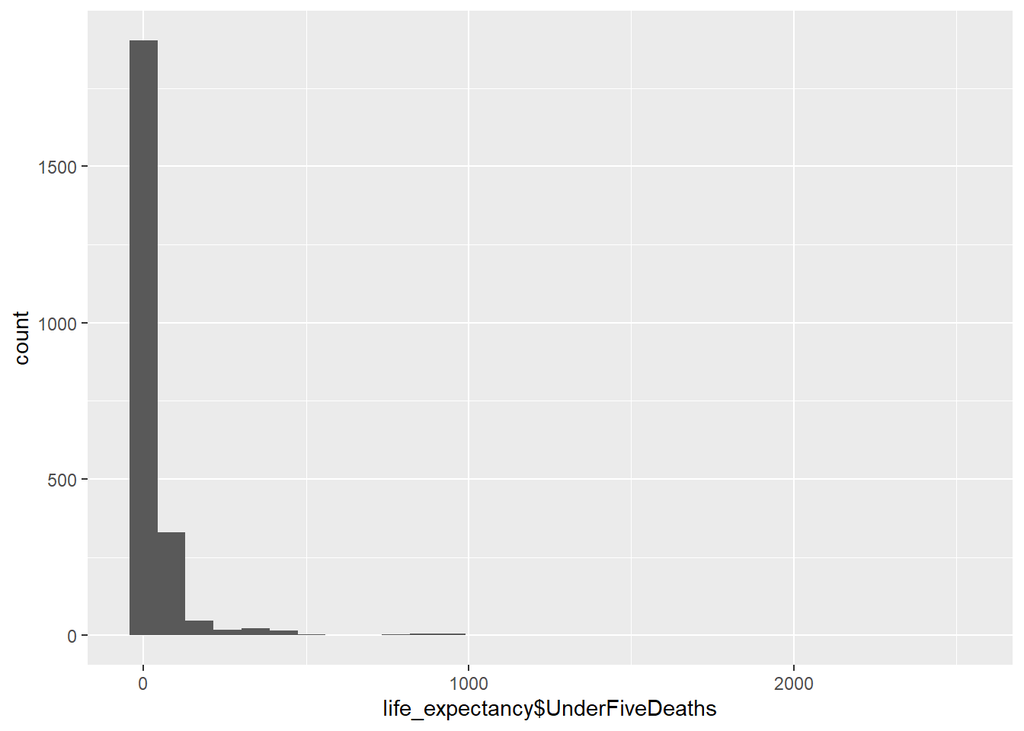

```r
#India 2000-2012 Mortality rate, under-5 (per 1,000 live births) https://data.worldbank.org/indicator/SH.DYN.MORT

#which(life_expectancy$Country == "India" & life_expectancy$Year == "2000")

life_expectancy %>% ggplot(aes(x=life_expectancy$UnderFiveDeaths))+geom_histogram()
```

```r
investigate_over200('UnderFiveDeaths')
```

```
## [1] 92
## # A tibble: 13 x 2
##     Year missing
##    <int>   <int>
##  1  2000       8
##  2  2001       8
##  3  2002       8
##  4  2003       8
##  5  2004       8
##  6  2005       8
##  7  2006       7
##  8  2007       7
##  9  2008       6
## 10  2009       6
## 11  2010       6
## 12  2011       6
## 13  2012       6
## # A tibble: 8 x 2
##   Country                          missing
##   <chr>                              <int>
## 1 Bangladesh                             8
## 2 China                                 13
## 3 Democratic Republic of the Congo      13
## 4 Ethiopia                              13
## 5 India                                 13
## 6 Indonesia                              6
## 7 Nigeria                               13
## 8 Pakistan                              13
```

```r
#Bangladesh- incorrect
#China- incorrect
#Democratic Republic of Congo- incorrect
#Ethiopia- incorrect
#Indonesia- incorrect
#Nigeria- incorrect
#Pakistan- incorrect

###DATA PREP: Merge Function for missing/incorrect data
# Fill incorrect UnerFiveDeaths data from secondary source: World Banks -- indicator code:  SH.DYN.MORT
wb_under5 <- wb_data(indicator = "SH.DYN.MORT", country = "countries_only", start_date = 2000, end_date = 2015)
# Grab only necessary columns and map to match dataset
wb_under5 <- wb_under5 %>% select(date, SH.DYN.MORT , country)
colnames(wb_under5) = c("Year", "UnderFiveDeaths", "Country")
```

## Polio

Description (from WHO): It’s probably referring to “immunization coverage among one-year-olds (%)”

## Total expenditure

Description (from WHO): Total expenditure on health as a percentage of gross domestic product 200 N/A (out of almost 3,000 observations)

## Diphtheria

Description (from WHO): Diphtheria tetanus toxoid and pertussis (DTP3) immunization coverage among 1-year-olds (%)

Missing values: very small number of missing values (8 in our reduced data) Data accuracy: minimum of 2 and maximum of 99, which makes sense given that it’s a percentage. Most of the data seems to make sense with a few exception: for example, United Republic of Tanzania, where it varies widely from year to year between 9 and 98

```r
investigate_missing_column_values("Diphtheria")
```

```
## [1] 8
## # A tibble: 6 x 2
##   Year.factor missing
##   <fct>         <int>
## 1 2000              2
## 2 2001              2
## 3 2002              1
## 4 2003              1
## 5 2004              1
## 6 2005              1
## # A tibble: 2 x 2
##   Country.factor missing
##   <fct>            <int>
## 1 Montenegro           6
## 2 Timor-Leste          2
```

## HIV/AIDS

Description: there are 23 indicators related to HIV on the WHO web site, I’m not sure which one it is

```r
investigate_missing_column_values("HIV_AIDS")
```

```
## [1] 0
## # A tibble: 0 x 2
## # ... with 2 variables: Year.factor <fct>, missing <int>
## # A tibble: 0 x 2
## # ... with 2 variables: Country.factor <fct>, missing <int>
```

## GDP

Countries’ corresponding economic data was collected from United Nation website 448 N/A (out of almost 3,000 observations)

```r
# What rows are missing GDP?
missing_GDP_indices <- which(is.na(life_expectancy[,'GDP']))
length(missing_GDP_indices)
```

```
## [1] 350
```

```r
investigate_missing_column_values("GDP")
```

```
## [1] 350
## # A tibble: 13 x 2
##    Year.factor missing
##    <fct>         <int>
##  1 2000             28
##  2 2001             27
##  3 2002             27
##  4 2003             27
##  5 2004             26
##  6 2005             26
##  7 2006             26
##  8 2007             26
##  9 2008             27
## 10 2009             27
## 11 2010             27
```

[output cut: 16 more lines]

```r
# Fill missing GDP data from secondary source: World Banks -- indicator code:  NY.GDP.PCAP.CD
GDP_per_capita <- wb_data(indicator = "NY.GDP.PCAP.CD", country = "countries_only", start_date = 2000, end_date = 2012)
# Grab only necessary columns and map to match dataset
GDP_per_capita <- GDP_per_capita %>% select(date, NY.GDP.PCAP.CD, country)
colnames(GDP_per_capita) = c("Year", "GDP", "Country")
# Check for name discrepancies
summary(comparedf(life_expectancy, GDP_per_capita, by = "Country", tol.vars = "Country"))
```

```
##
##
## Table: Summary of data.frames
##
## version   arg                ncol   nrow
## --------  ----------------  -----  -----
## x         life_expectancy      25   2366
## y         GDP_per_capita        3   2821
##
##
##
## Table: Summary of overall comparison
##
## statistic                                                      value
## ------------------------------------------------------------  ------
## Number of by-variables                                             1
## Number of non-by variables in common                               2
## Number of variables compared                                       1
## Number of variables in x but not y                                22
## Number of variables in y but not x                                 0
## Number of variables compared with some values unequal              1
## Number of variables compared with all values equal                 0
## Number of observations in common                               26364
## Number of observations in x but not y                            338
## Number of observations in y but not x                            793
## Number of observations with some compared variables unequal     2015
## Number of observations with all compared variables equal       24349
## Number of values unequal                                       26151
##
##
##
## Table: Variables not shared
##
## version   variable                 position  class
## --------  ----------------------  ---------  --------
## x         Status                          3  factor
## x         LifeExpectancy                  4  numeric
## x         AdultMortality                  5  integer
## x         InfantDeaths                    6  integer
## x         Alcohol                         7  numeric
```

[output cut: 1181 more lines]

```
## GDP     GDP     Afghanistan   198.7285   543.303        10      24
## GDP     GDP     Afghanistan   198.7285   NA             10      14
## GDP     GDP     Afghanistan   198.7285   591.1628       10      25
## GDP     GDP     Afghanistan   198.7285   263.7337       10      20
## GDP     GDP     Afghanistan   198.7285   NA             10      15
## GDP     GDP     Afghanistan   198.7285   211.3821       10      18
## GDP     GDP     Afghanistan   198.7285   641.8715       10      26
##
##
##
## Table: Non-identical attributes
##
## var.x   var.y   name
## ------  ------  ------
## GDP     GDP     label
```

```r
# Country Name Corrections to match b/w GDP and Kaggle Life Expectancy dataset
GDP_per_capita[,'Country'] <- sub(", The", "", GDP_per_capita$Country)
GDP_per_capita[,"Country"] <- sub("Bolivia", "Bolivia (Plurinational State of)", GDP_per_capita$Country)
GDP_per_capita[,'Country'] <- sub("Congo, Dem. Rep.", "Democratic Republic of the Congo", GDP_per_capita$Country)
GDP_per_capita[,'Country'] <- sub("Congo, Rep.", "Congo", GDP_per_capita$Country)
GDP_per_capita[,'Country'] <- sub("Cote d'Ivoire", "Côte d'Ivoire", GDP_per_capita$Country)
GDP_per_capita[,'Country'] <- sub("Czech Republic", "Czechia", GDP_per_capita$Country)
GDP_per_capita[,"Country"] <- sub("Democratic Republic of the Congo", "Congo", GDP_per_capita$Country)
GDP_per_capita[,'Country'] <- sub("Korea, Dem. People's Rep.", "Democratic People's Republic of Korea", GDP_per_capita$Country)
GDP_per_capita[,'Country'] <- sub("Egypt, Arab Rep.", "Egypt", GDP_per_capita$Country)
GDP_per_capita[,'Country'] <- sub("Gambia, The", "Gambia", GDP_per_capita$Country)
GDP_per_capita[,'Country'] <- sub("Iran, Islamic Rep.", "Iran (Islamic Republic of)", GDP_per_capita$Country)
GDP_per_capita[,'Country'] <- sub("Kyrgyz Republic", "Kyrgyzstan", GDP_per_capita$Country)
GDP_per_capita[,'Country'] <- sub("Lao PDR", "Lao People's Democratic Republic", GDP_per_capita$Country)
GDP_per_capita[,'Country'] <- sub("Micronesia, Fed. Sts.", "Micronesia (Federated States of)", GDP_per_capita$Country)
GDP_per_capita[,'Country'] <- sub("Korea, Rep.", "Republic of Korea", GDP_per_capita$Country)
GDP_per_capita[,'Country'] <- sub("Moldova", "Republic of Moldova", GDP_per_capita$Country)
GDP_per_capita[,'Country'] <- sub("St. Lucia", "Saint Lucia", GDP_per_capita$Country)
GDP_per_capita[,'Country'] <- sub("St. Vincent and the Grenadines", "Saint Vincent and the Grenadines", GDP_per_capita$Country)
GDP_per_capita[,'Country'] <- sub("Slovak Republic", "Slovakia", GDP_per_capita$Country)
GDP_per_capita[,'Country'] <- sub("Eswatini", "Swaziland", GDP_per_capita$Country)
GDP_per_capita[,'Country'] <- sub("North Macedonia", "The former Yugoslav republic of Macedonia", GDP_per_capita$Country)
GDP_per_capita[,'Country'] <- sub("United Kingdom", "United Kingdom of Great Britain and Northern Ireland", GDP_per_capita$Country)
GDP_per_capita[,'Country'] <- sub("Tanzania", "United Republic of Tanzania", GDP_per_capita$Country)
GDP_per_capita[,'Country'] <- sub("United States", "United States of America", GDP_per_capita$Country)
GDP_per_capita[,'Country'] <- sub("Venezuela, RB", "Venezuela (Bolivarian Republic of)", GDP_per_capita$Country)
GDP_per_capita[,'Country'] <- sub("Vietnam", "Viet Nam", GDP_per_capita$Country)
GDP_per_capita[,'Country'] <- sub("Yemen, Rep.", "Yemen", GDP_per_capita$Country)

summary(comparedf(life_expectancy, GDP_per_capita, by = "Country", tol.vars = "Country"))
```

```
##
##
## Table: Summary of data.frames
##
## version   arg                ncol   nrow
## --------  ----------------  -----  -----
## x         life_expectancy      25   2366
## y         GDP_per_capita        3   2821
##
##
##
## Table: Summary of overall comparison
##
## statistic                                                      value
## ------------------------------------------------------------  ------
## Number of by-variables                                             1
## Number of non-by variables in common                               2
## Number of variables compared                                       1
## Number of variables in x but not y                                22
## Number of variables in y but not x                                 0
## Number of variables compared with some values unequal              1
## Number of variables compared with all values equal                 0
## Number of observations in common                               30758
## Number of observations in x but not y                             13
## Number of observations in y but not x                            455
## Number of observations with some compared variables unequal     2327
## Number of observations with all compared variables equal       28431
## Number of values unequal                                       30376
##
##
##
## Table: Variables not shared
##
## version   variable                 position  class
## --------  ----------------------  ---------  --------
## x         Status                          3  factor
## x         LifeExpectancy                  4  numeric
## x         AdultMortality                  5  integer
## x         InfantDeaths                    6  integer
## x         Alcohol                         7  numeric
```

[output cut: 518 more lines]

```
## GDP     GDP     Afghanistan   669.959    242.0313        1      19
## GDP     GDP     Afghanistan   669.959    211.3821        1      18
## GDP     GDP     Afghanistan   669.959    263.7337        1      20
## GDP     GDP     Afghanistan   669.959    190.6838        1      17
## GDP     GDP     Afghanistan   669.959    NA              1      15
## GDP     GDP     Afghanistan   669.959    543.303         1      24
## GDP     GDP     Afghanistan   669.959    591.1628        1      25
##
##
##
## Table: Non-identical attributes
##
## var.x   var.y   name
## ------  ------  ------
## GDP     GDP     label
```

```r
miss_var_summary(life_expectancy)
```

```
## # A tibble: 25 x 3
##    variable            n_miss pct_miss
##    <chr>                <int>    <dbl>
##  1 Population             521   22.0
##  2 HepatitisB             510   21.6
##  3 GDP                    350   14.8
##  4 IncCompOfResources     130    5.49
##  5 Schooling              130    5.49
##  6 TotalExpenditure        29    1.23
##  7 BMI                     13    0.549
##  8 Thinness_1_19_years     13    0.549
##  9 Thinness_5_9_years      13    0.549
## 10 Polio                    8    0.338
## # ... with 15 more rows
```

```r
# Merge life_expectancy and GDP_per_capita on Year and Country to fill in GDP
life_expectancy <- left_join(life_expectancy, GDP_per_capita, by = c("Country", "Year")) %>%
    mutate(GDP = coalesce(GDP.x, GDP.y)) %>%
    select(-GDP.x,-GDP.y)

miss_var_summary(life_expectancy)
```

```
## # A tibble: 25 x 3
##    variable            n_miss pct_miss
##    <chr>                <int>    <dbl>
##  1 Population             534   22.4
##  2 HepatitisB             517   21.7
##  3 IncCompOfResources     130    5.46
##  4 Schooling              130    5.46
##  5 GDP                     50    2.10
##  6 TotalExpenditure        29    1.22
##  7 BMI                     13    0.546
##  8 Thinness_1_19_years     13    0.546
##  9 Thinness_5_9_years      13    0.546
## 10 Polio                    8    0.336
## # ... with 15 more rows
```

## Population

700 N/A (out of almost 3,000 observations) Min is probably wrong (population of 34?) – Maldives 2003

```r
miss_var_summary(life_expectancy)
```

```
## # A tibble: 25 x 3
##    variable            n_miss pct_miss
##    <chr>                <int>    <dbl>
##  1 Population             534   22.4
##  2 HepatitisB             517   21.7
##  3 IncCompOfResources     130    5.46
##  4 Schooling              130    5.46
##  5 GDP                     50    2.10
##  6 TotalExpenditure        29    1.22
##  7 BMI                     13    0.546
##  8 Thinness_1_19_years     13    0.546
##  9 Thinness_5_9_years      13    0.546
## 10 Polio                    8    0.336
## # ... with 15 more rows
```

```r
#Looking at missing values
investigate_missing_column_values("Population")
```

```
## [1] 534
## # A tibble: 13 x 2
##    Year.factor missing
##    <fct>         <int>
##  1 2000             41
##  2 2001             41
##  3 2002             41
##  4 2003             41
##  5 2004             41
##  6 2005             41
##  7 2006             41
##  8 2007             41
##  9 2008             41
## 10 2009             41
## 11 2010             41
```

[output cut: 16 more lines]

```r
summary(life_expectancy$Population)
```

```
##      Min.   1st Qu.    Median      Mean   3rd Qu.      Max.      NA's
## 3.400e+01 1.823e+05 1.342e+06 1.234e+07 6.947e+06 1.180e+09       534
```

```r
#investigate minimum population value: Maldives, should be 302683
min(life_expectancy[,18], na.rm=T)
```

```
## [1] 0.1
```

```r
which.min(life_expectancy[,18])
```

```
## [1] 1132
```

```r
print(life_expectancy[1615,])
```

```
##               Country Year     Status LifeExpectancy AdultMortality
## 1615 Papua New Guinea 2010 Developing           61.8            286
##      InfantDeaths Alcohol PercentageExpenditure HepatitisB Measles  BMI
## 1615           10    0.79              18.99962         56       0 44.9
##      UnderFiveDeaths Polio TotalExpenditure Diphtheria HIV_AIDS Population
## 1615              14    72             4.18         67      1.1     718239
##      Thinness_1_19_years Thinness_5_9_years IncCompOfResources Schooling
## 1615                 1.4                1.3              0.485       9.6
##        Country.factor Year.factor Developed      GDP
## 1615 Papua New Guinea        2010         0 1366.879
```

```r
#List all missing rows
missing_pop_indices <- which(is.na(life_expectancy[,'Population']))
length(missing_pop_indices)
```

```
## [1] 534
```

```r
#Which countries do we need to import data for?
miss_pop <- life_expectancy %>% filter(is.na(life_expectancy[,'Population'])) #all missing pop data
miss_pop$Country <- as.factor(miss_pop$Country)
levels(miss_pop$Country)
```

```
##  [1] "Antigua and Barbuda"
##  [2] "Bahamas"
##  [3] "Bahrain"
##  [4] "Barbados"
##  [5] "Bolivia (Plurinational State of)"
##  [6] "Brunei Darussalam"
##  [7] "Congo"
##  [8] "Côte d'Ivoire"
##  [9] "Cuba"
## [10] "Czechia"
## [11] "Democratic People's Republic of Korea"
## [12] "Democratic Republic of the Congo"
## [13] "Egypt"
## [14] "Eritrea"
## [15] "Gambia"
```

[output cut: 26 more lines]

```r
#Import World Bank Population Data: https://data.worldbank.org/indicator/SP.POP.TOTL
wb_pop <- wb_data(indicator = "SP.POP.TOTL", country = "countries_only", start_date = 2000, end_date = 2012)
# Grab only necessary columns and map to match dataset
wb_pop <- wb_pop %>% select(date, SP.POP.TOTL, country)
colnames(wb_pop) = c("Year", "Population", "Country")

#Columns that need to be renamed in order to merge (WB data is missing Cook Islands and Niue)
wb_pop[,'Country'] <- sub("Bahamas, The", "Bahamas", wb_pop$Country)
wb_pop[,'Country'] <- sub("Bolivia", "Bolivia (Plurinational State of)", wb_pop$Country)
wb_pop[,'Country'] <- sub("Congo, Rep.", "Congo", wb_pop$Country)
wb_pop[,'Country'] <- sub("Cote d'Ivoire", "Côte d'Ivoire", wb_pop$Country)
wb_pop[,'Country'] <- sub("Czech Republic", "Czechia", wb_pop$Country)
wb_pop[,'Country'] <- sub("Korea, Dem. People's Rep.", "Democratic People's Republic of Korea", wb_pop$Country)
wb_pop[,'Country'] <- sub("Congo, Dem. Rep.", "Democratic Republic of the Congo", wb_pop$Country)
wb_pop[,'Country'] <- sub("Egypt, Arab Rep.", "Egypt", wb_pop$Country)
wb_pop[,'Country'] <- sub("Gambia, The", "Gambia", wb_pop$Country)
wb_pop[,'Country'] <- sub("Iran, Islamic Rep.", "Iran (Islamic Republic of)", wb_pop$Country)
wb_pop[,'Country'] <- sub("Kyrgyz Republic", "Kyrgyzstan", wb_pop$Country)
wb_pop[,'Country'] <- sub("Lao PDR", "Lao People's Democratic Republic", wb_pop$Country)
wb_pop[,'Country'] <- sub("Micronesia, Fed. Sts.", "Micronesia (Federated States of)", wb_pop$Country)
wb_pop[,'Country'] <- sub("Korea, Rep.", "Republic of Korea", wb_pop$Country)
wb_pop[,'Country'] <- sub("Moldova", "Republic of Moldova", wb_pop$Country)
wb_pop[,'Country'] <- sub("St. Kitts and Nevis", "Saint Kitts and Nevis", wb_pop$Country)
wb_pop[,'Country'] <- sub("St. Lucia", "Saint Lucia", wb_pop$Country)
wb_pop[,'Country'] <- sub("St. Vincent and the Grenadines", "Saint Vincent and the Grenadines", wb_pop$Country)
wb_pop[,'Country'] <- sub("Slovak Republic", "Slovakia", wb_pop$Country)
wb_pop[,'Country'] <- sub("North Macedonia", "The former Yugoslav republic of Macedonia", wb_pop$Country)
wb_pop[,'Country'] <- sub("United Kingdom", "United Kingdom of Great Britain and Northern Ireland", wb_pop$Country)
wb_pop[,'Country'] <- sub("United States", "United States of America", wb_pop$Country)
wb_pop[,'Country'] <- sub("Tanzania", "United Republic of Tanzania", wb_pop$Country)
wb_pop[,'Country'] <- sub("Venezuela, RB", "Venezuela (Bolivarian Republic of)", wb_pop$Country)
wb_pop[,'Country'] <- sub("Vietnam", "Viet Nam", wb_pop$Country)
wb_pop[,'Country'] <- sub("Yemen, Rep.", "Yemen", wb_pop$Country)


# ###DATA PREP: Merge Function for missing/incorrect data
# # Fill mising Population data from secondary source: World Banks -- indicator code:  SP.POP.TOTL
# wb_pop2 <- wb_data(indicator = "SP.POP.TOTL", country = "countries_only", start_date = 2000, end_date = 2015)
# # Grab only necessary columns and map to match dataset
# wb_pop2 <- wb_pop2 %>% select(date, SP.POP.TOTL , country)
# colnames(wb_pop2) = c("Year", "Population", "Country")

# life_expectancy_pop <- merge(life_expectancy, wb_pop2, by = c("Country","Year"))
# # which(is.na(life_expectancy_pop[,'Population']))
miss_var_summary(life_expectancy)
```

```
## # A tibble: 25 x 3
##    variable            n_miss pct_miss
##    <chr>                <int>    <dbl>
##  1 Population             534   22.4
##  2 HepatitisB             517   21.7
##  3 IncCompOfResources     130    5.46
##  4 Schooling              130    5.46
##  5 GDP                     50    2.10
##  6 TotalExpenditure        29    1.22
##  7 BMI                     13    0.546
##  8 Thinness_1_19_years     13    0.546
##  9 Thinness_5_9_years      13    0.546
## 10 Polio                    8    0.336
## # ... with 15 more rows
```

```r
life_expectancy <- left_join(life_expectancy, wb_pop, by = c("Country", "Year")) %>%
    mutate(Population = coalesce(Population.x, Population.y)) %>%
    select(-Population.x,-Population.y)


miss_var_summary(life_expectancy)
```

```
## # A tibble: 25 x 3
##    variable            n_miss pct_miss
##    <chr>                <int>    <dbl>
##  1 HepatitisB             517   21.7
##  2 IncCompOfResources     130    5.46
##  3 Schooling              130    5.46
##  4 GDP                     50    2.10
##  5 TotalExpenditure        29    1.22
##  6 BMI                     13    0.546
##  7 Thinness_1_19_years     13    0.546
##  8 Thinness_5_9_years      13    0.546
##  9 Polio                    8    0.336
## 10 Diphtheria               8    0.336
## # ... with 15 more rows
```

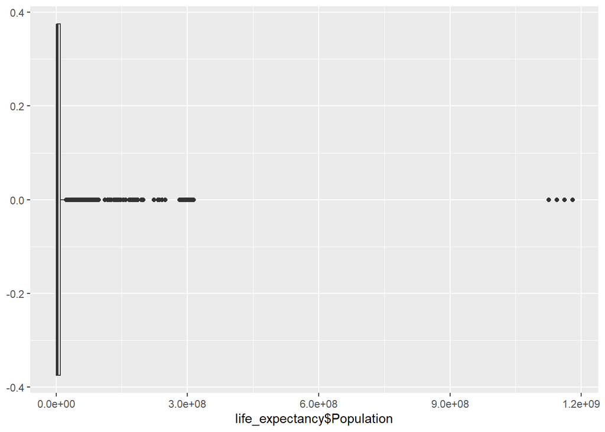

```r
life_expectancy %>% ggplot(aes(x=life_expectancy$Population))+geom_boxplot()
```

```r
summary(life_expectancy$Population)
```

```
##      Min.   1st Qu.    Median      Mean   3rd Qu.      Max.      NA's
## 3.400e+01 2.775e+05 2.035e+06 1.479e+07 9.175e+06 1.180e+09         1
```

```r
le_ordered <- life_expectancy[order(life_expectancy$Population),]
tail(le_ordered,20)
```

```
##                       Country Year     Status LifeExpectancy AdultMortality
## 991                 Indonesia 2010 Developing           68.1            187
## 989                 Indonesia 2012 Developing           68.5            183
## 2275 United States of America 2000  Developed           76.8            114
## 2274 United States of America 2001  Developed           76.9            115
## 2273 United States of America 2002  Developed           77.0            115
## 2272 United States of America 2003  Developed           77.2            114
## 2271 United States of America 2004  Developed           77.5            111
## 2270 United States of America 2005  Developed           77.5            112
## 2269 United States of America 2006  Developed           77.8            113
## 2268 United States of America 2007  Developed           78.1             11
## 2267 United States of America 2008  Developed           78.2             18
## 2266 United States of America 2009  Developed           78.5             18
## 2265 United States of America 2010  Developed           78.7             15
## 2264 United States of America 2011  Developed           78.7             16
```

[output cut: 90 more lines]

```r
head(le_ordered,50)
```

```
##                     Country Year     Status LifeExpectancy AdultMortality
## 1323               Maldives 2003 Developing           72.7            112
## 1317               Maldives 2009 Developing           76.3             75
## 811                 Georgia 2008 Developing           73.9            128
## 952                 Hungary 2010  Developed           74.5            156
## 2137                  Tonga 2008 Developing           72.6            145
## 2141                  Tonga 2004 Developing           72.2            151
## 1326               Maldives 2000 Developing           69.6            139
## 1325               Maldives 2001 Developing           78.0            129
## 1324               Maldives 2002 Developing           71.8            124
## 1322               Maldives 2004 Developing           73.4             16
## 1321               Maldives 2005 Developing           74.3             93
## 1320               Maldives 2006 Developing           75.0             88
## 1319               Maldives 2007 Developing           75.4             82
## 1318               Maldives 2008 Developing           75.9             81
```

[output cut: 240 more lines]